# Coursework Report

*N* removed NAs: 2

*N* removed typo: 1

*N* removed <18: 24

*N* total clean: 124

| Group | *N* | *M*<sub>age</sub> | *M*<sub>rating</sub> |
| --- | --- | --- | --- |
| Control | 59 | 20.76 | 6.28 |
| Experim | 65 | 20.52 | 5.64 |

**Main analysis results**

*t*(122) = 4.77, *p* < .001

[interactive chart not shown]

[figure not shown]

[interactive chart not shown]

# Coursework Report

Analysing Data, Spring 2020

# Methods

## Participants

Table 1: The Mean Age of Participants

| Mean | SD | Min-age | Max-age |
| --- | --- | --- | --- |
| 20.64 | 1.77 | 18 | 26 |

## Design

The conceptual hypothesis of this study is that women find men more attractive when associated with red. The research question based on this is: “Will women find an averagely attractive man more attractive when he is pictured framed in red, as opposed to framed in white?”. The women are each asked two questions: “How attractive do you think this person is?”, “How pleasant is this person to look at?”. Finally, they are asked to respond to the statement “If I were to meet the person in this picture face to face, I would think he is attractive”. They are asked to give an answer to all three on a 1-9 rating scale where 1 is low (not attractive at all) and 9 is high (very attractive). The independent variable is the colour of the border around the picture of the man (red or white). The operational hypothesis of this study is that women will find a picture of an averagely attractive man more attractive on a rating scale of 1-9, where 1 is low and 9 is high, when the picture has a red background rather than a white one. A *t*-test will be conducted to analyse the results comparing the mean attractiveness ratings given by the women in the experimental (red background) condition and the control (white background) condition.

# Results

This study investigated whether participants would give better attractiveness ratings to images of men with a red border, compared to a white border. An independent measures *t*-test was used to analyse the results. The results did not support the hypothesis as the control (white border) group scored the men as more attractive on average (*M* = 6.28) than the experimental (red border) group(*M* = 5.64). This difference in mean values was found to be significant (*M*<sub>diff</sub> = 0.65 , 95% CI [0.38 , 0.91], *t* (122) = 4.77, *p* = .00001) (Table 2). These results suggest that, the colour red does not have a positive effect on how attractive women found men, as had been initially hypothesised, it may in fact have a negative impact on women’s view of how attractive they found a man.

Table 2: The Mean Attractiveness Ratings

| Group | Mean | SD |
| --- | --- | --- |
| control | 6.28 | 0.89 |
| experimental | 5.64 | 0.61 |

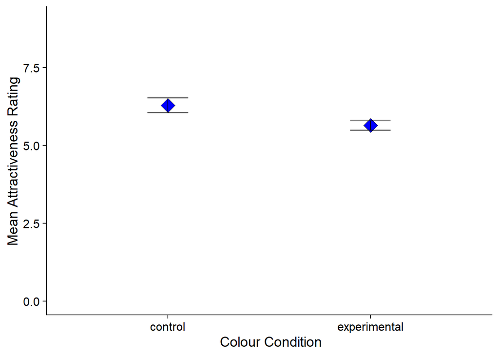

# Discussion

Colour has been shown to be a factor in attraction and mating in the animal kingdom, for example it has been suggested that red colouration on the faces of male macaques signals a higher quality mate (Waitt et al., 2003). This relationship between red and attraction has yet to be proven in humans. This study collected data that provided credence to the argument that red does not have a positive impact on how attractive women find men, in fact this study found that women rated an averagely attractive man with a white border as more attractive than the same averagely attractive man with a red border. The difference in mean attraction was found to be significant by an independent measures *t*-test. This study was a replication of “Experiment 1” which was done by Elliott et al. (2010) as part of a larger study into red and attraction in which they found data suggesting the opposite, that red did make women more attracted to a man. The difference in the results could be down to the issue that only 21 students were used in the Elliot et al. study, whereas this study used a sample of 124. A smaller sample and the use of only a single picture of a man means that if the experimental group of women found the man more naturally attractive than the control group, or vice versa, it could skew the data. This is less likely in a larger sample. Other researchers have performed replications of Elliot’s experiments, one of which found that, in both a replication and an extended replication of Elliot’s experiments, red had no statistically significant effect on a man’s perceived attractiveness (Hesslinger et al., 2015).

Continuing the theme of cited research in this field not holding up well to replication, Pollet et al. (2019) conducted two replications of a previous study (Lin, 2014), looking into ownership of red objects and whether they increase the attraction felt toward those objects’ owners. Neither of these replications found any discerning evidence that red objects impacted perceived attractiveness. Both of these studies had large sample sizes, at least 2.5 times the size of the original sample (study 1: 273 Dutch men, study 2: 208 Chinese men) allowing the findings to be more reliably extrapolated to cover a population than the findings of the original.

The mentioned replications, along with the one conducted for this study suggest that previous research may have been incorrect. This could be a result of the sample sizes, both original studies used markedly smaller sample sizes than that of their respective replications, finding opposing results. These replications are not binding however. They, along with the originals have their own set of limitations that should be mentioned and explored before a more concrete conclusion can be drawn. One of Hesslinger’s studies was the only experiment to use multiple pictures of people. Meaning plenty of participants in the other studies could have simply not been attracted to the person in the picture, regardless of colour. More research should be done with a variety of pictures of people, of all levels of perceived attractiveness. It may be the case that it can improve the attractiveness of someone already perceived that way but cannot make someone attractive if we did not already think of them that way. This issue could be simply remedied by replicating the same studies again, using pictures of people rated to be unattractive, averagely attractive and very attractive. Furthermore, more research should be done in the form of in person studies. It could be the case that red has more of an impact on attractiveness when someone is rated in person, as opposed to in a picture. Finally, other age groups need to be researched, all of the mentioned studies used participants with a mean age under 25, meaning these results cannot be reliably applied to other age groups. It may be the case that colour has a differing impact on people of different ages. This would be a simple replication to perform, as exactly the same procedures as the above studies could be used.

In conclusion, this replication of a previous study has found results which contradict those of the orginal study; a higher mean attraction rating in the control group, rather than the experimental group. These results were found while using a larger sample size, within the same age bracket as the original. This style of replication has been performed on multiple occasions, on similar studies, with similar conclusions. Following the data gathered from these studies, along with this one, the only conclusion that can be made with any degree of certainty is that red does not seem to cause a discernible increase in the perceived attractiveness of men, in women.

# References

Elliot, A. J., Niesta Kayser, D., Greitemeyer, T., Lichtenfeld, S., Gramzow, R. H., Maier, M. A., & Liu, H. (2010). Red, rank, and romance in women viewing men. Journal of Experimental Psychology: General, 139(3), 399–417. https://doi.org/10.1037/a0019689

Hesslinger, V. M., Goldbach, L., & Carbon, C.-C. (2015). Men in red: A reexamination of the red-attractiveness effect. Psychonomic Bulletin & Review, 22(4), 1142–1148. https://doi.org/10.3758/s13423-015-0866-8

Lin, H. (2014). Red-colored products enhance the attractiveness of women. Displays, 35(4), 202–205. https://doi.org/10.1016/j.displa.2014.05.009

Pollet, T. V., Costello, J., Groeneboom, L., Peperkoorn, L. S., & Wu, J. (2019). Do red objects enhance sexual attractiveness? No evidence from two large replications. Displays, 56, 23–29. https://doi.org/10.1016/j.displa.2018.10.008

Waitt, C., Little, A. C., Wolfensohn, S., Honess, P., Brown, A. P., Buchanan-Smith, H. M., & Perrett, D. I. (2003). Evidence from rhesus macaques suggests that male coloration plays a role in female primate mate choice. Proceedings of the Royal Society of London. Series B: Biological Sciences, 270(suppl_2), S144–S146. https://doi.org/10.1098/rsbl.2003.0065